# Week 5- Introduction to NLP

Natural Language Processing (NLP) is a deep and fascinating field in the intersection of lingustics and the computing sciences. For this session, we'll only be touching on common NLP preprocessing techniques, topic classification and information retrieval.

Why study NLP? Here's coming at it with different perspectives:

1) **NLP is a key determinant of Artificial generalized intelligence** -- something that we can converse with as naturally as we do with humans.

2) An engineer's view: **unstructured data dominates structured data**.

3) **The market for NLP products is estimated to reach $13.4 BILLION by 2020** (marketsandmarkets.com). Startups and established incumbents that have mastery of this field can rake in the cash.

# Breadth of NLP

## NLP Systems

NLP can be thought of as a spectrum, from rule-based systems to probablistic systems.

1) Rule-based systems

- historical NLP systems took in a lot of linguistic literature, particularly grammars

2) Probablistic systems

- modern NLP takes into account massive text or audio datasets, commonly called corpora in literature. Words, characters, thought and topics are taken as events, and probabilities are computed according to empirical observations in the corpus.

3) Hybrid systems

- the more successful systems are not wholly rule-based nor probablistic. Grammars are inherent in human conversation, and advances in linguistics are complimented by computation.

## NLP Topics

### 1) Sequence modeling

- how do we model sequences of characters and words?
- character segmentation, spelling correction

```python
from IPython.display import display, Image
display(Image(
        url="http://iconictranslation.com/wp-content/uploads/2014/10/Screen-Shot-2014-10-01-at-11.01.06.png"))
```

[output not shown]

### 2) Language modeling

- Human languages are complex and to model it is a valuable exercise.
- Probablistic-context-free grammars (PCFG), part-of-speech tagging, parse trees and dependency graphs

```python
display(Image(
        url="http://conglang.github.io/img/note_nlp_a_probabilistic_context_free_grammar.png"),
       Image(
        url="http://conglang.github.io/img/note_nlp_parsing_syntactic_structure.png"))
```

[figure not shown]

### 3) Machine translation

- perhaps the most important and most difficult application of NLP.
- statistical alignment, word and structure disambiguation

```python
display(Image(url="http://conglang.github.io/img/note_nlp_an_example_alignment.png"))
```

[figure not shown]

### 4) Audio Signal Processing

- requires mastery of language modeling and signal processing
- DFT's, MFCC, grammar, pronunciation models

```python
display(Image(url="https://buffy.eecs.berkeley.edu/PHP/resabs/images/2005/100672-0.gif"))
```

[figure not shown]

### 5) Information Extraction

- used to make some structure out of unstructured text
- named entity recognition, co-reference extraction, relation extraction, document summarization

```python
display(Image(url="http://ai.cs.washington.edu/www/media/icons/pubs/Screen_shot_2010-09-11_at_9.36.44_AM.png"))
```

[output not shown]

### 6) Topic classification and Information Retrieval

- Topic classification is today's lecture, this covers sentiment analysis, content classification

For an in-depth discussion on NLP, I recommend these books:

```python
display(Image(url="http://ecx.images-amazon.com/images/I/41NDG5DHQHL._SX354_BO1,204,203,200_.jpg",width=200, height=200),
        Image(url="http://ecx.images-amazon.com/images/I/51j6JCrBd-L._SX379_BO1,204,203,200_.jpg",width=200, height=200))
```

[figure not shown]

# NLp ToolKit (NLTK)

NLTK is an open sourced library in python for NLP tasks. We can use it to preprocess, analyze and refine our data for further machine learning tasks.

First, we'll load up the Reuters corpus, a collection of 10K news documents published in 1987 categorized into 90 different topics. Let's have some fun using NLTK first, before we get any more serious.

```python
%matplotlib inline
import numpy as np
import matplotlib.pyplot as plt
import nltk
```

```python
from nltk.corpus import reuters
len(reuters.words())
```

```
1720901
```

```python
reuters.categories()
```

```
[u'acq',
 u'alum',
 u'barley',
 u'bop',
 u'carcass',
 u'castor-oil',
 u'cocoa',
 u'coconut',
 u'coconut-oil',
 u'coffee',
 u'copper',
 u'copra-cake',
 u'corn',
 u'cotton',
 u'cotton-oil',
 u'cpi',
 u'cpu',
 u'crude',
 u'dfl',
 u'dlr',
 u'dmk',
 u'earn',
 u'fuel',
 u'gas',
 u'gnp',
 u'gold',
 u'grain',
 u'groundnut',
 u'groundnut-oil',
 u'heat',
 u'hog',
 u'housing',
 u'income',
 u'instal-debt',
 u'interest',
 u'ipi',
 u'iron-steel',
 u'jet',
 u'jobs',
 u'l-cattle',
```

[output cut: 35 more lines]

```
 u'soy-oil',
 u'soybean',
 u'strategic-metal',
 u'sugar',
 u'sun-meal',
 u'sun-oil',
 u'sunseed',
 u'tea',
 u'tin',
 u'trade',
 u'veg-oil',
 u'wheat',
 u'wpi',
 u'yen',
 u'zinc']
```

```python
nltk.Text(reuters.words(categories=['jobs'])).concordance("government")
```

```
Displaying 25 of 51 matches:
ee pct of GDP . While the Belgian government has made progress in trimming its
nnounced recently by the Japanese government to encourage public works and cut
n May , the worst level since the government started compiling unemployment st
ployment statistics in 1953 , the government ' s Management and Coodination Ag
eceive a boost on Friday when the government announces a reflationary budget f
iscal year ends December 31 . The government has said it expects 1987 growth t
r of cocoa , timber and oil . The government slashed development spending to 9
. 2 billion ringgit deficit . The government has said its fiscal policies will
in 1986 was 952 mln ringgit . The government will also repay some of its exter
 . Businessmen said they hope the government also will cut the corporate tax ,
record 3 . 0 pct in January , the government ' s Management and Coordination A
p boost growth . But whatever the government ' s response , the central bank w
see a key parliamentary debate on government finances and the economy . Mercha
ployment is bottoming out and the government has already admitted it will not
interest rates down to reduce the government debt burden . A Finance Ministry
 way too early for that ." FRENCH GOVERNMENT TO STEP UP AID TO JOBLESS The gov
ENT TO STEP UP AID TO JOBLESS The government plans to go ahead with a three bi
 to everyone becoming redundant , government officials said . At present only
l come from a 7 . 5 billion franc government fund set up last month to finance
m 6 . 3 pct last year , urged the government to cut expenditure further to bri
curity payments in future . Dutch government revenue is being depressed furthe
e current year . Nomura urged the government to take pump - priming measures t
e current year . Nomura urged the government to take pump - priming measures t
NCES PLAN TO BOOST EMPLOYMENT The government announced a three billion franc p
 one third of French unemployed , government figures show . The main measures
```

```python
nltk.Text(reuters.words(categories=['jobs'])).similar("government")
```

```
fed cpb dollar oecd bank department economy report guilder budget
right surplus economists yen trend money ec scb autumn year
```

```python
nltk.Text(reuters.words(categories=['trade'])).similar("government")
```

```
japanese ec dollar ministry administration deficit market trade
agreement talks president bank tariffs country economy committee issue
industry report commission
```

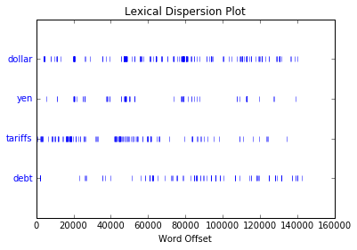

```python
nltk.Text(reuters.words(categories=['trade'])).dispersion_plot(["dollar", "yen","tariffs","debt"])
```

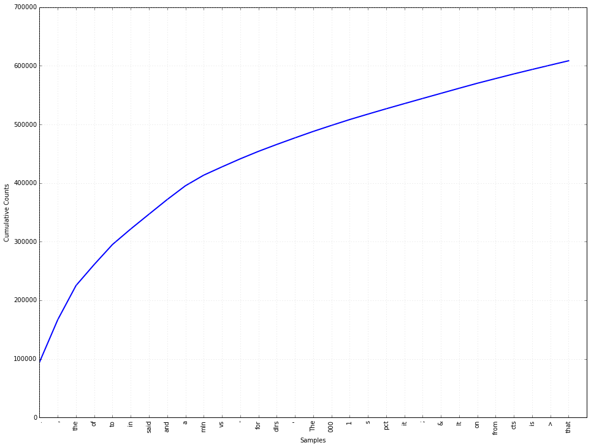

```python
fdist = nltk.FreqDist(reuters.words())
fig, ax = plt.subplots(figsize=(16,12))
ax = fdist.plot(30, cumulative=True)
```

```python
stopwords = nltk.corpus.stopwords.words()
cleansed_words = [w.lower() for w in reuters.words() if w.isalnum() and w.lower() not in stopwords]
fdist = nltk.FreqDist(cleansed_words)
fdist.most_common(30)
```

```
[(u'said', 25383),
 (u'mln', 18623),
 (u'vs', 14341),
 (u'dlrs', 12417),
 (u'000', 10277),
 (u'1', 9977),
 (u'pct', 9810),
 (u'lt', 8696),
 (u'cts', 8361),
 (u'year', 7529),
 (u'net', 6989),
 (u'2', 6528),
 (u'billion', 5829),
 (u'loss', 5124),
 (u'3', 5091),
 (u'5', 4683),
 (u'would', 4673),
 (u'company', 4670),
 (u'1986', 4392),
 (u'4', 4363),
 (u'shr', 4182),
 (u'inc', 4121),
 (u'bank', 3654),
 (u'7', 3450),
 (u'corp', 3399),
 (u'6', 3376),
 (u'oil', 3272),
 (u'last', 3243),
 (u'8', 3218),
 (u'share', 3160)]
```

```python
# we can also parse text
def parse(document):
    sentences = nltk.sent_tokenize(document)
    sentences = [nltk.word_tokenize(sent) for sent in sentences]
    sentences = [nltk.pos_tag(sent) for sent in sentences]
    return sentences

sentences = parse(' '.join(reuters.sents()[100]))
```

```python
sentences[0]
```

```
[(u'Now', 'RB'),
 (u'it', 'PRP'),
 (u"'", "''"),
 (u's', 'RBR'),
 (u'largely', 'RB'),
 (u'out', 'IN'),
 (u'of', 'IN'),
 (u'their', 'PRP$'),
 (u'hands', 'NNS'),
 (u',', ','),
 (u"''", "''"),
 (u'said', 'VBD'),
 (u'Kleinwort', 'NNP'),
 (u'Benson', 'NNP'),
 (u'Ltd', 'NNP'),
 (u'financial', 'JJ'),
 (u'analyst', 'NN'),
 (u'Simon', 'NNP'),
 (u'Smithson', 'NNP'),
 (u'.', '.')]
```

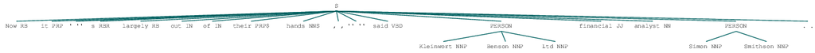

```python
nltk.ne_chunk(sentences[0])
```

```python
viz=nltk.ne_chunk(sentences[0])
print viz
```

```
(S
  Now/RB
  it/PRP
  '/''
  s/RBR
  largely/RB
  out/IN
  of/IN
  their/PRP$
  hands/NNS
  ,/,
  ''/''
  said/VBD
  (PERSON Kleinwort/NNP Benson/NNP Ltd/NNP)
  financial/JJ
  analyst/NN
  (PERSON Simon/NNP Smithson/NNP)
  ./.)
```

# Load up my own corpus

We made a corpus off my own student days regarding the PH Senatorial Race of 2013. It's a relatively small corpus, but for topic classification, we'll use this.

Take note that NLTK can load corpora off the web, from RSS feeds, Twitter and other websites.

```python
from nltk.corpus.reader import CategorizedPlaintextCorpusReader
sens = CategorizedPlaintextCorpusReader('data/ExtractedSenatorSpeeches',
                                        r'.+/.*\.html', cat_pattern=r'(.+)/.*\.html')
sens.categories()
```

```
['ACayetano',
 'Chiz',
 'Guingona',
 'JPE',
 'Jinggoy',
 'Koko',
 'Loren',
 'Miriam',
 'Pia',
 'Trillanes']
```

## Q: Go and try out the methods above. Grab some interesting insights.

# How about some supervised learning?

This is an example of data whose features is unknown. Obviously, we use the words, not the characters, since a single word expresses **a thought that can explain the category**. On the other hand, these English or Filipino characters don't. However, we have another challenge. How do we represent these words as features? This is the problem of feature representation, and here we introduce the bag-of-words (BOW) representation.

BOW is a matrix defined by $\mathbb{M} \in \mathbb{R}^{mxn}$ where m represents documents in the corpus for $i=0...m$ and n represent word features for $j=0...n$. Matrix values $c_{i,j}$ could be ${0,1}$, $\mathbb{Z}$ (counts) or $\mathbb{Q}^+$ (frequencies).

In BOW, each word is then treated separately. There are pros and cons in such a representation:

Pros:

1) Very fast to compute.

2) Easy to store.

Cons:

1) Words are not totally independent. N-grams can serve to alleviate this, but what about long term dependencies? Consider the following:

```
Jack, although poor, received honors for their academic performance.
```

2) Word-sense disambiguation. Consider how monstrous is used in following sentences:

```
You shuddered as you gazed, and wondered what monstrous cannibal and savage could ever have gone a death-harvesting with such a hacking, horrifying implement.

She is a monstrous lucky girl to get him, upon my honour; not but that he is much more lucky in getting her, because she is so very handsome and agreeable, that nothing can be good enough for her.
```

We'll use scikit learn to "vectorize" our data.

```python
display(Image(
        url="http://image.slidesharecdn.com/nlp-introduction-en-150515082725-lva1-app6891/95/natural-language-processing-nlp-introduction-21-638.jpg?cb=1431679296"))
```

[figure not shown]

```python
from sklearn.feature_extraction.text import CountVectorizer
tagalog_stopwords = ["mga","sina","si","ang","sila","kami", "tayo","amin","inyo","iyo",
                     "ako","akin","kayo","siya","kanila","ikaw","o","at","kung","kaya","kaya't", "saka",
                    "ay"]
all_stopwords = stopwords+tagalog_stopwords
vectorizer = CountVectorizer(stop_words=all_stopwords, strip_accents="unicode")
vectorizer
```

[output not shown]

```python
files = [f for f in sens.fileids()]
corpus = [sens.raw(fileids=[f]) for f in files]
```

```python
X = vectorizer.fit_transform(corpus)
X.shape
```

```
(1118, 28610)
```

```python
vectorizer.get_feature_names()[2000:2030]
```

```
[u'analysis',
 u'analysts',
 u'analyze',
 u'analyzed',
 u'analyzers',
 u'analyzing',
 u'anarchic',
 u'anarchism',
 u'anarchy',
 u'anathema',
 u'anay',
 u'anc',
 u'ancestors',
 u'ancestral',
 u'ancestry',
 u'anchor',
 u'anchored',
 u'ancient',
 u'ancillary',
 u'andabove',
 u'andaman',
 u'andanar',
 u'andand',
 u'andauditing',
 u'andaya',
 u'andcohorts',
 u'andito',
 u'andiyan',
 u'andmisleading',
 u'andoon']
```

```python
y = [sens.categories(fileids=f)[0] for f in files]
```

```python
from sklearn import cross_validation as cv
X_train, X_test, \
    y_train, y_test = cv.train_test_split(X, y,
                                          test_size=0.33)
```

# New Model: Naive Bayes

The Naive Bayes classifier is a probablistic classifier, using the maximum likelihood estimates and the Bayes rule. (reference: cs.colostate.edu, nlp.stanford.edu)

## What is maximum likelihood?

Given feature vector $x^{(1)} = (x_1, x_2, ... x_n)$:

$$ \begin{align} P(x^{(1)}|\theta) & = P(x_1 | \theta_1) P(x_2 | \theta_2) ... P(x_n | \theta_n) \\ & = \prod_{i=1}^{n}P(x_i|\theta_i) \end{align} $$

We say this is a maximum likelihood solution since we find $\theta$ that maximize $P(X|\theta)$.

## Classification

Now, applying this to classification, we have in probability:

$$ P(Y|X) = \frac{P(X|Y) P(Y)}{P(X)} $$

where $P(Y|X)$ is called the posterior, $P(X|Y)$ is called the likelihood and $P(Y)$ is called the prior.

For classification, $P(X)$ is not so important since we'll be only using the **maximum a posteriori (MAP)** rule, that is:

$$ \begin{align} \operatorname{arg\,max}_y P(Y|X) & = \operatorname{arg\,max}_y \frac{P(X|Y) P(Y)}{P(X)}\\ & = \operatorname{arg\,max}_y P(X|Y) P(Y) \end{align} $$

Taking this into text classification:

$$ P(c|d) \propto P(c) \prod_{1 \le k \le n_d} P(t_k|c) $$

Since this can cause underflow, we use sum of log probabilities:

$$ P(c|d) \propto log P(c) + \sum_{1 \le k \le n_d} log P(t_k|c) $$

where $P(t_k|c)$ is the conditional probability of term $t_k$ appearing in a document of class c. That is,

$$ \hat{P}(t_k|c) = \frac{T_{ct}}{\sum_{t \in V} T_{ct}} $$

where $T_{ct}$ is the number of occurences of term i in training documents from class c. We're discarding where term t appeared in the document.

Lastly, we just get the MAP class: $$ c_{map} = \operatorname{arg\,max}_{c \in \mathbb{C}} log P(c) + \sum_{1 \le k \le n_d} log P(t_k|c) $$

### Laplace Smoothing

What if a word in the vocabulary does not appear in the dictionary? Thus $\hat{P}(t_k|c)$ becomes 0. We generally don't want zeroes in our computations. Thus, we do smoothing:

$$ \hat{P}(t_k|c) = \frac{T_{ct}+1}{\sum_{t \in V} T_{ct}+|V|} $$

Example!

**Table 13.1:** Data for parameter estimation examples.

|  |  | docID | words in document | in china? (c) |  |
| --- | --- | --- | --- | --- | --- |
|  | training set | 1 | Chinese Beijing Chinese | yes |  |
|  |  | 2 | Chinese Chinese Shanghai | yes |  |
|  |  | 3 | Chinese Macao | yes |  |
|  |  | 4 | Tokyo Japan Chinese | no |  |
|  | test set | 5 | Chinese Chinese Chinese Tokyo Japan | ? |  |

```python
display(Image(url="http://nlp.stanford.edu/IR-book/html/htmledition/img902.png"))
```

[figure not shown]

```python
display(Image(url="http://nlp.stanford.edu/IR-book/html/htmledition/img907.png"))
```

[figure not shown]

### Pros and Cons:

**Pros:**

1) NB is probably the easiest classifiers to implement and understand.

2) Storage-wise, it's very effective.

3) Computation at testing time is also very fast.

**Cons:**

1) Extending it may require understanding different statistical distributions (more of a caveat really)

2) Requires I.I.D, that is, all features are independent of each other.

Even though NB is simple, it has worked well in practice, particularly, text classification, where there are a lot of words. It does not suffer as much from the curse of dimensionality since the decoupling of the class conditional feature distributions means that each distribution can be independently estimated as a one dimensional distribution. (from sklearn)

# Back to Codes

```python
scores = cv.cross_val_score(MultinomialNB(), X,y,cv=10)
print scores
print np.mean(scores)
print np.std(scores)
```

```
[ 0.76068376  0.81034483  0.63793103  0.80357143  0.79279279  0.79279279
  0.76363636  0.79816514  0.87037037  0.85185185]
0.788214036038
0.0596766029195
```

```python
from sklearn.naive_bayes import MultinomialNB
from sklearn.metrics import classification_report

# train the classifier
classifier = MultinomialNB()
classifier.fit(X_train, y_train)

# predict labels for the test set
predictions = classifier.predict(X_test)

# output the classification report
label_names = list(set(y_test))
print(classification_report(y_test, predictions, target_names=label_names))
```

```
             precision    recall  f1-score   support

       Chiz       0.97      0.77      0.86        44
       Koko       0.46      1.00      0.63         6
        Pia       1.00      0.38      0.55        21
        JPE       0.64      0.93      0.75        68
     Miriam       1.00      0.96      0.98        24
    Jinggoy       0.74      0.70      0.72        20
  Trillanes       0.85      0.93      0.89       102
   Guingona       0.69      0.50      0.58        18
  ACayetano       1.00      0.23      0.38        13
      Loren       0.89      0.74      0.80        53

avg / total       0.83      0.80      0.79       369
```

```python
dir(classifier)
```

```
['__abstractmethods__',
 '__class__',
 '__delattr__',
 '__dict__',
 '__doc__',
 '__format__',
 '__getattribute__',
 '__hash__',
 '__init__',
 '__module__',
 '__new__',
 '__reduce__',
 '__reduce_ex__',
 '__repr__',
 '__setattr__',
 '__sizeof__',
 '__str__',
 '__subclasshook__',
 '__weakref__',
 '_abc_cache',
 '_abc_negative_cache',
 '_abc_negative_cache_version',
 '_abc_registry',
 '_count',
 '_estimator_type',
 '_get_coef',
 '_get_intercept',
 '_get_param_names',
 '_joint_log_likelihood',
 '_update_class_log_prior',
 '_update_feature_log_prob',
 'alpha',
 'class_count_',
 'class_log_prior_',
 'class_prior',
 'classes_',
 'coef_',
 'feature_count_',
 'feature_log_prob_',
 'fit',
 'fit_prior',
 'get_params',
 'intercept_',
 'partial_fit',
 'predict',
 'predict_log_proba',
 'predict_proba',
 'score',
 'set_params']
```

```python
classifier.class_log_prior_
```

```
array([-2.19989838, -3.97968165, -2.88106937, -1.56888298, -2.62975494,
       -2.68691335, -1.42024195, -3.06339092, -3.62300671, -1.89135116])
```

```python
classifier.feature_log_prob_.shape
```

```
(10, 28610)
```

### How to find the words that are the largest pieces of evidence for a senator?

```python
inds = classifier.feature_log_prob_[2].argsort()[-20:][::-1]
inds
```

```
array([18068, 10302,  4072, 13084,  5278, 20876, 11023, 12887, 23873,
       10834, 21737, 23877, 10042,  9957, 14194,  3697, 23397, 23054,
       26138, 16221])
```

```python
np.asarray(vectorizer.get_feature_names())[inds]
```

```
array([u'ng', u'government', u'budget', u'jueteng', u'committee', u'po',
       u'hindi', u'ito', u'senate', u'hearing', u'public', u'senator',
       u'general', u'garcia', u'law', u'blue', u'said', u'ribbon', u'tg',
       u'may'],
      dtype='<U32')
```

```python
inds = classifier.feature_log_prob_[1].argsort()[-20:][::-1]
inds
```

```
array([18068, 11023, 20876, 13776,  2609, 17862, 12887, 14074, 19082,
       14042, 16221, 18076, 19140, 12578, 12756, 28569, 23489, 14111,
       23099,  6327])
```

```python
np.asarray(vectorizer.get_feature_names())[inds]
```

```
array([u'ng', u'hindi', u'po', u'ko', u'ating', u'natin', u'ito',
       u'lamang', u'pa', u'lahat', u'may', u'ngayon', u'pag', u'inyong',
       u'isang', u'yung', u'sana', u'lang', u'rin', u'dahil'],
      dtype='<U32')
```

# TF-IDF Weighting

TF-IDF is used to strike a balance between rare words and common words. What we want really is to find words that are **important** to a class, even if it is rare. It is computed by the following:

$$ \text{tf-idf}_{t,d} = \text{tf}_{t,d} * idf_t\\ $$$$ idf_t = log \frac{N}{df_t} $$

```python
from sklearn.feature_extraction.text import TfidfVectorizer
vectorizer = TfidfVectorizer(stop_words=all_stopwords)
vectorizer
```

```
TfidfVectorizer(analyzer=u'word', binary=False, decode_error=u'strict',
        dtype=<type 'numpy.int64'>, encoding=u'utf-8', input=u'content',
        lowercase=True, max_df=1.0, max_features=None, min_df=1,
        ngram_range=(1, 1), norm=u'l2', preprocessor=None, smooth_idf=True,
        stop_words=[u'og', u'i', u'jeg', u'det', u'at', u'en', u'den', u'til', u'er', u'som', u'p\xe5', u'de', u'med', u'han', u'af', u'for', u'ikke', u'der', u'var', u'mig', u'sig', u'men', u'et', u'har', u'om', u'vi', u'min', u'havde', u'ham', u'hun', u'nu', u'over', u'da', u'fra', u'du', u'ud', u…
        strip_accents=None, sublinear_tf=False,
        token_pattern=u'(?u)\\b\\w\\w+\\b', tokenizer=None, use_idf=True,
        vocabulary=None)
```

```python
y_tfidf = [sens.categories(fileids=f)[0] for f in files]

files = [f for f in sens.fileids()]
corpus = [sens.raw(fileids=[f]) for f in files]

X_tfidf = vectorizer.fit_transform(corpus)
X_tfidf.shape
```

```
(1118, 28610)
```

```python
X_tfidf_train, X_tfidf_test, \
    y_tfidf_train, y_tfidf_test = cv.train_test_split(X_tfidf, y_tfidf,
                                          test_size=0.33)
```

```python
scores = cv.cross_val_score(MultinomialNB(), X_tfidf,y_tfidf,cv=10)
print scores
print np.mean(scores)
print np.std(scores)
```

```
[ 0.53846154  0.60344828  0.51724138  0.58928571  0.59459459  0.59459459
  0.55454545  0.49541284  0.60185185  0.66666667]
0.575610291421
0.0472493161177
```

```python
# train the classifier
classifier = MultinomialNB()
classifier.fit(X_tfidf_train, y_tfidf_train)

# predict labels for the test set
predictions = classifier.predict(X_tfidf_test)

# output the classification report
label_names = list(set(y_tfidf_train))
print(classification_report(y_tfidf_test, predictions, target_names=label_names))
```

```
             precision    recall  f1-score   support

       Chiz       1.00      0.54      0.70        39
       Koko       0.00      0.00      0.00         3
        Pia       0.00      0.00      0.00        19
        JPE       0.35      1.00      0.51        59
     Miriam       0.00      0.00      0.00        30
    Jinggoy       1.00      0.09      0.17        22
  Trillanes       0.74      0.99      0.85       112
   Guingona       0.00      0.00      0.00        16
  ACayetano       0.00      0.00      0.00        13
      Loren       1.00      0.45      0.62        56

avg / total       0.60      0.59      0.52       369
```

```python
inds = classifier.feature_log_prob_[0].argsort()[-20:][::-1]
np.asarray(vectorizer.get_feature_names())[inds]
```

```
array([u'said', u'senator', u'government', u'people', u'listening',
       u'farmers', u'senate', u'industry', u'leader', u'tour', u'ptk',
       u'pdaf', u'percent', u'prices', u'country', u'ofws', u'help',
       u'vendors', u'support', u'jobs'],
      dtype='<U32')
```

## Filtering some more & n-grams

```python
from sklearn.feature_extraction.text import TfidfVectorizer
vectorizer = TfidfVectorizer(stop_words=all_stopwords, max_df=0.9, min_df=0.01)

y_tfidf = [sens.categories(fileids=f)[0] for f in files]

files = [f for f in sens.fileids()]
corpus = [sens.raw(fileids=[f]) for f in files]

X_tfidf = vectorizer.fit_transform(corpus)
X_tfidf.shape
```

```
(1118, 5048)
```

```python
scores = cv.cross_val_score(MultinomialNB(), X_tfidf,y_tfidf,cv=10)
print scores
print np.mean(scores)
print np.std(scores)
```

```
[ 0.68376068  0.71551724  0.59482759  0.69642857  0.69369369  0.68468468
  0.66363636  0.66972477  0.67592593  0.7037037 ]
0.678190322506
0.0315093350954
```

```python
from sklearn.feature_extraction.text import TfidfVectorizer
vectorizer = TfidfVectorizer(stop_words=all_stopwords, max_df=0.9, min_df=0.01, ngram_range=(1,2))

y_tfidf = [sens.categories(fileids=f)[0] for f in files]

files = [f for f in sens.fileids()]
corpus = [sens.raw(fileids=[f]) for f in files]

X_tfidf = vectorizer.fit_transform(corpus)
X_tfidf.shape
```

```
(1118, 6346)
```

```python
scores = cv.cross_val_score(MultinomialNB(), X_tfidf,y_tfidf,cv=10)
print scores
print np.mean(scores)
print np.std(scores)
```

```
[ 0.68376068  0.71551724  0.63793103  0.72321429  0.72072072  0.69369369
  0.67272727  0.67889908  0.73148148  0.73148148]
0.698942697801
0.0291978018392
```

## Q: Try using min_df=0.001 and then compare

## Visualization using PCA

```python
from sklearn import decomposition

pca = decomposition.PCA(n_components=3)
X_tfidf_pca = pca.fit_transform(X_tfidf.toarray())
```

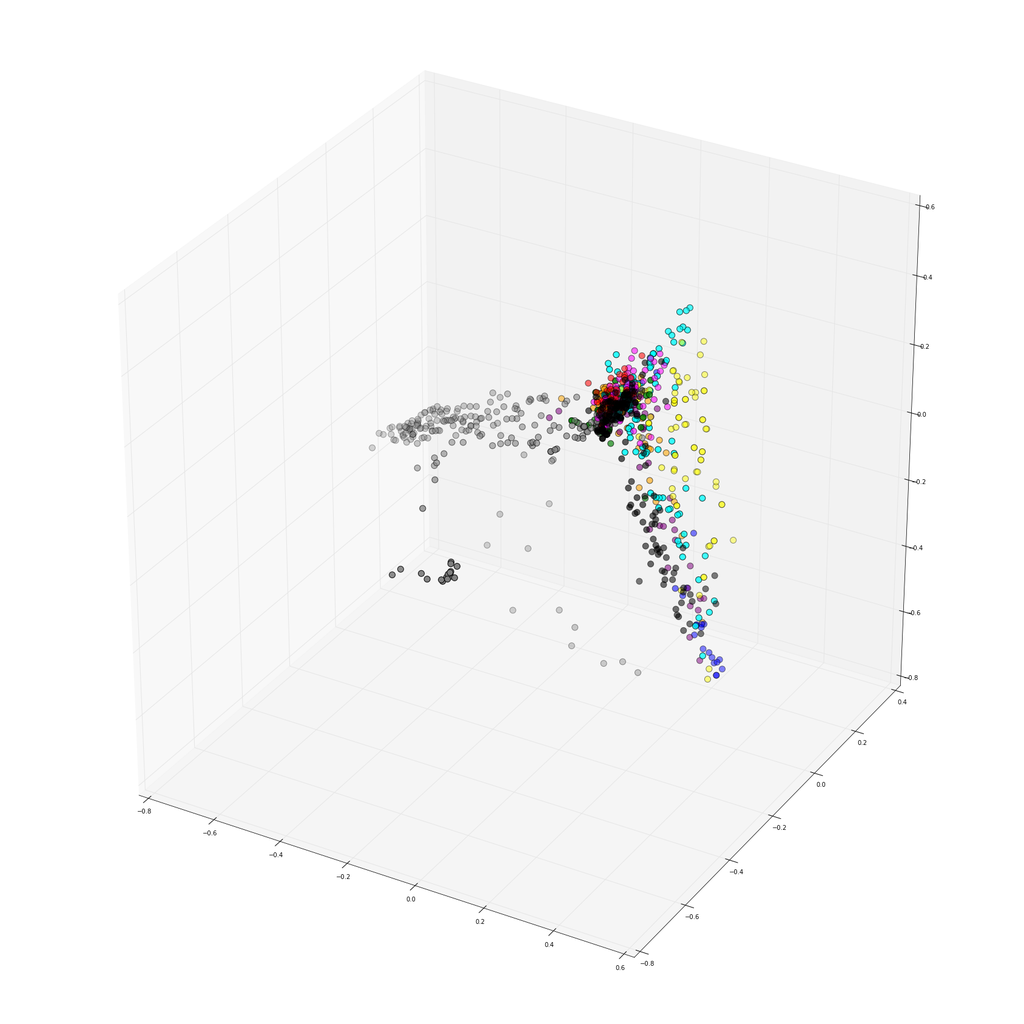

```python
from mpl_toolkits.mplot3d import Axes3D
fig = plt.figure(figsize=(30,30))
ax = fig.add_subplot(111, projection='3d')

label_names = list(set(y_tfidf))
color_wheel = {"Chiz": "blue", "Koko":"green",
               "Pia":"red", "JPE":"cyan", "Miriam":"magenta",
              "Jinggoy":"yellow","Trillanes":"black",
               "Guingona":"purple","ACayetano":"orange","Loren":"gray"}
c=map(lambda x:color_wheel[x], y)

plt.figure(figsize=(20,20))
ax.scatter(X_tfidf_pca[:,0],X_tfidf_pca[:,1],X_tfidf_pca[:,2],c=c,s=100,zdir="y")
```

# Homework!

Answer Kaggle's Random Acts of Pizza dataset, a dataset that contains text columns, as well as dates, integers, etc. https://www.kaggle.com/c/random-acts-of-pizza/data

The task here is to predict "requester_received_pizza".

Some helpful steps:

1) This is JSON format. Do the appropriate preprocessing to convert it into a Pandas dataframe.

2) Use first the text columns alone (request_title and request_text_edit_aware). Establish your baseline.

3) Include some features you think are useful, and you can represent in a meaningful way. Timestamps, for example, could be represented by some other feature instead, like requester_account_age_in_days_at_request. Id's, of course, are not useful (save for the last step, submission)

- To "append" columns, use np.hstack

4) Use sklearn's Pipeline to automate searching of the parameters.

5) Repeat 3 until happy.

6) [For the advanced]. Use a separate model for the text and another separate model for the other features. Combine the two predictions by having another model learn from the previous models' log probabilities / outputs.